# Discriminant analysis and classification

Mar 17 2026

**ISLR**

· **Chapter 4**: Classification

o Section 4.1: An Overview of Classification

o Section 4.4: Generative Models for Classification

§ Section 4.4.1-4.4.2: Linear Discriminant Analysis

§ Section 4.4.3: Quadratic Discriminant Analysis

**R Book**

· **Chapter 25**: Multivariate Statistics

o Section 25.5: Discriminant Analysis

## “Separating and predicting”

1. Discrimination/Classification
- Separating objects in an existing data set
- Find which variables that best separate the \(K\) groups
- Predict group membership for a new observation
- Allocate new objects to known groups

## Classification problems: data setup

- For each case \(i = 1,\ldots,n\) we observe  
  response \(y_i\) and predictors \(\mathbf{x}_i = (x_{i1}, \ldots, x_{ip})\).
- We have \(n\) data cases (rows in the data set).
- We have \(p\) predictor variables.
- **Regression**
  - \(y_i\) is quantitative. Predictors \(\mathbf{x}_i\) are typically continuous (may include factors).
- **Classification**
  - \(y_i\) is categorical with \(K\) classes (factor with \(K\) levels). Predictors \(\mathbf{x}_i\) are usually continuous, but may be factors.

## Classification versus clustering

- **Clustering**
  - We *search for groups* in the data.
  - No prior information about which groups and how many.
  - Often based only on the predictors \(\mathbf{x}_i\).
  - Example: group customers by purchasing patterns.
  - This is **unsupervised learning**.
- **Classification**
  - The groups (classes) are *given in advance* through the response \(y_i\).
  - We try to explain or predict group membership using \(\mathbf{x}_i\).
  - Example: predict disease status from biomarkers.
  - This is **supervised learning**.

## Example: The iris data

- This famous (Fisher’s or Anderson’s) iris data set gives the measurements in centimeters of the variables X1=sepal length, X2=sepal width, X3=petal length and X4=petal width, respectively
- Can we classify based on X-variables?
- What’s the best method?

```
##     Sepal.Length Sepal.Width Petal.Length Petal.Width    Species
## 5            5.0         3.6          1.4         0.2     setosa
## 55           6.5         2.8          4.6         1.5 versicolor
## 125          6.7         3.3          5.7         2.1  virginica
```

## Pairs plot

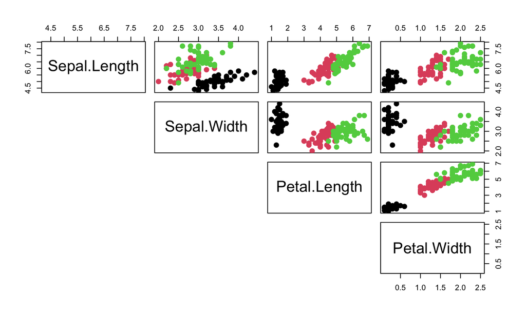

## Example 2: Lizards

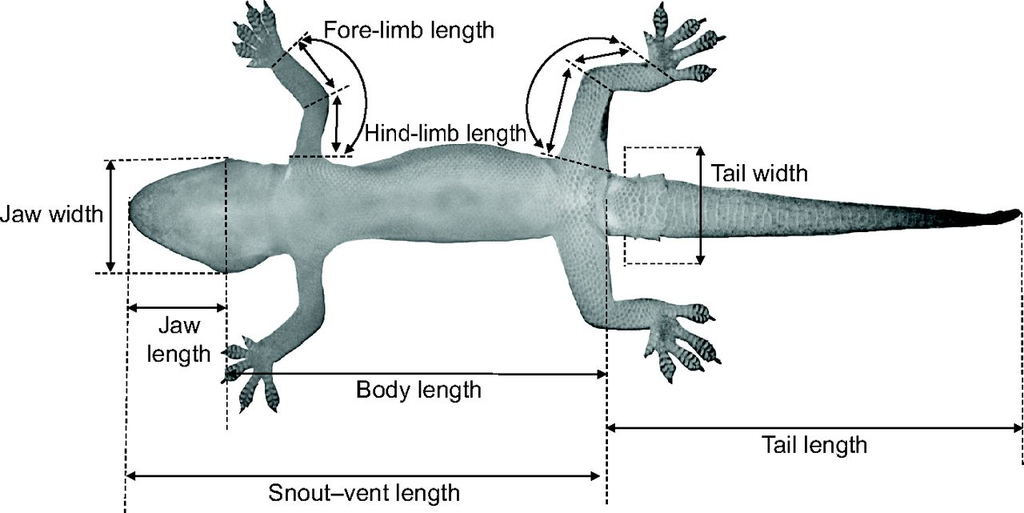

## Example 2: Lizards

We have in addition to sex measured \(p=3\) variables on lizards:

- Mass : Weight of lizard (in grams)
- SVL : Snout-vent length (in millimeters)
- HLS : Hind limb span (in millimeters)

Can we discriminate Sex on the basis of the body measures?

```
##     Mass  SVL   HLS Sex
## 1  5.526 59.0 113.5   f
## 2 10.401 75.0 142.0   m
## 3  9.213 69.0 124.0   f
## 4  8.953 67.5 125.0   f
## 5  7.063 62.0 129.5   m
```

## Pairs plot - gender colored

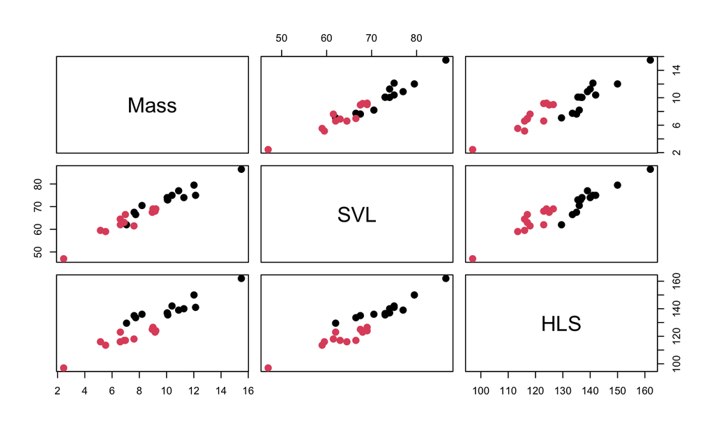

## Finding decision regions

In discriminant analysis we search for decision regions for the \(K\) known groups (classes).

Regions \(R_1, R_2, \ldots, R_K\)

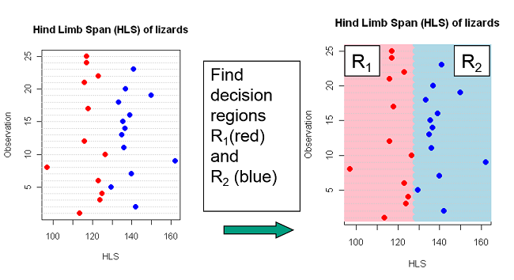

## Most probable group

- Perfect discrimination/classification may not be possible.
- The idea is to find decision regions \(R_1, R_2, \ldots, R_K\) that minimizes the probability of doing misclassification.
- *Intuitively we would allocate an observation to the group which is most probable given the observed value of the predictors*
- If, for example, the HLS of a new lizard is 130, it seems most probable based on previous data that the lizard is a male.

## Bayes theorem: Recap

For two events \(A\) and \(B\):

\[ P(A \mid B) = \frac{P(B \mid A)\,P(A)}{P(B)}. \]

- \(P(A)\): probability that \(A\) occurs.
- \(P(B \mid A)\): probability that \(B\) occurs, given that \(A\) has occurred.
- \(P(A \mid B)\): probability that \(A\) occurs, given that \(B\) has occurred.
- \(P(B)\): probability that \(B\) occurs.

## Bayes theorem: Recap

\[ P(A \mid B) = \frac{P(B \mid A)\,P(A)}{P(B)}=\frac{P(A\cdot B)}{P(B)}. \]

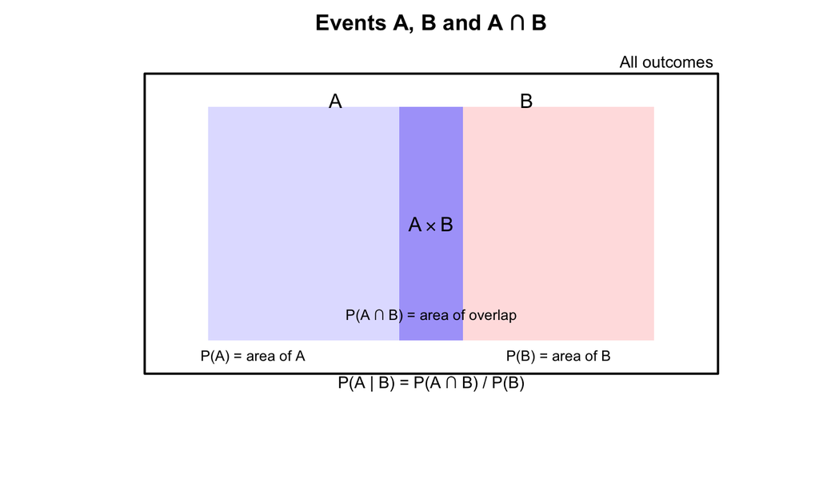

## Bayes theorem: color blindness example

- C = “person is color blind”
- M = “person is male”, F = “person is female”
- P(M) = 0.52 ⇒ P(F) = 0.48
- P(C | M) = 0.08 (8% of men are color blind)
- P(C | F) = 0.02 (2% of women are color blind)

## **Law of total probability (in simple words)**

P(M) = 0.52 ⇒ P(F) = 0.48 and P(C | M) = 0.08 and P(C | F) = 0.02

To find the **overall chance that a random person is color blind**, we add:  
“chance of picking a man who is color blind”

+ “chance of picking a woman who is color blind \(P(C) = P(C \mid M) P(M) + P(C \mid F) P(F)\) \(= 0.08 \cdot 0.52 + 0.02 \cdot 0.48 = 0.052.\)

So about 5.2% of the population is color blind.

## **Bayes theorem (female given color blind)**

- P(M) = 0.52 ⇒ P(F) = 0.48 and P(C | M) = 0.08 and P(C | F) = 0.02

  We now flip the question: **given that a person is color blind, what is the chance this person is a woman?** \(P(F \mid C) = \frac{P(C \mid F) P(F)}{P(C)} = \frac{0.02 \cdot 0.48}{0.02 \cdot 0.48 + 0.08\cdot 0.52} \approx 0.185\)

So if you meet a color blind person, there is about an 18.5% chance that this person is a woman.

## Bayes for LDA: Lizard example

**Goal:** Find the probability that a lizard is **male** given we observed HLS = 130.

For two classes: female \(c_f\) and male \(c_m\), and observed HLS \(x\) \(\color{blue}{P(c_m \mid x) = \frac{P(x \mid c_m)\,P(c_m)}{P(x)} = \frac{P(x \mid c_m)\,P(c_m)}{P(x \mid c_m)\,P(c_m) + P(x \mid c_f)\,P(c_f)}}\).

- \(P(c_m)\), \(P(c_f)\): **priors** (how common males/females are). Example: 50% males, 50% females (no prior preference)
- \(P(x \mid c_m)\), \(P(x \mid c_f)\): **probabilities** (how likely HLS = \(x\) is in each group). E.g. how probable is HLS = 130 with each sex?
- \(P(c_m \mid x)\): **posterior** (probability the lizard is male given \(x\) is HLS = 130).

## Bayes example: high HLS → male likely

- Prior: \(P(c_m) = 0.5\), \(P(c_f) = 0.5\).
- Likelihood (probability) at \(x = 130\): say  
  \(P(x \mid c_m) = 0.04\), \(P(x \mid c_f) = 0.01\).

Then

\[ P(c_m \mid x) = \frac{0.04 \cdot 0.5}{0.04 \cdot 0.5 + 0.01 \cdot 0.5} = \frac{0.02}{0.02 + 0.005} \approx 0.80. \]

So with HLS = 130 we would classify this lizard as **male**.

## Low HLS → female likely

Consider again a low HLS value \(x = 110\).

- Prior probabilities (**now** males more common):
  - \(P(c_m) = 0.7\)
  - \(P(c_f) = 0.3\)
- Likelihood (probability) at \(x = 110\) (value fits females better):
  - \(P(x \mid c_m) = 0.01\)
  - \(P(x \mid c_f) = 0.05\)
- \[ P(c_f \mid x) = \frac{0.05 \cdot 0.3}{0.05 \cdot 0.3 + 0.01 \cdot 0.7} = \frac{0.015}{0.015 + 0.007} \approx 0.68. \]

Even though males are more common overall, for HLS = 110 the lizard is still more likely to be **female**.

## Many classes

Using Bayes theorem we find the probability that the object belongs to class \(c_i\) given one observed value \(x\):

\[ P(c_i \mid x) = \frac{P(x \mid c_i)\,P(c_i)} {\sum_{j=1}^K P(x \mid c_j)\,P(c_j)}. \]

- The denominator is constant \(const= \sum_{j=1}^K P(x \mid c_j) P(c_j)\) ensures that the class probabilities \(P(c_i \mid x)\) add up to 1.

In compact notation with \(P(c_i \mid x) \propto P(c_i)\,P(x \mid c_i),\)

and for continuous \(x\) we have the likelihood \(f\) function \(P(c_i \mid x) \propto P(c_i)\,f(x \mid c_i),\)

which we often summarize as \(\color{red}{\text{Posterior}} \propto \color{blue}{\text{Prior}} \times \color{green}{\text{Likelihood}}.\)

## Linear Discriminant Analysis (LDA)

**Starting simple: One covariate**

In LDA we **assume** that the predictor(s) follow a *normal distribution* within each class.

For the lizard example with one variable (\(x_1\) = HLS):

- For class 1 (females): \(x|c_1 \sim N(\mu_1, \sigma^2)\)
- For class 2 (males): \(x|c_2 \sim N(\mu_2, \sigma^2)\)

**Key assumption**: *Common variance* \(\sigma^2\) for both classes, but possibly different means

We estimate \(\mu_1\), \(\mu_2\) and \(\sigma^2\) from the training data.

## LDA: Classification rule (one covariate)

Assume prior probabilities for females and males, e.g.: \(p_1 = p_2 = 0.5\)

Assume \(x_1\) = HLS is the only predictor.

From the data we estimate \(\mu_1\), \(\mu_2\) and common \(\sigma^2\) for both classes. Let \(f_1 = N(\widehat{\mu}_1, \widehat{\sigma}^2)\) and \(f_2= N(\widehat{\mu}_2, \widehat{\sigma}^2)\).

**Classification rule**: Classify a new lizard as *female* if it is more likely a posteriori

\[\color{blue}{\frac{p(c_f|x^*)}{p(c_m|x^*)} =\frac{f_1(x^*)\cdot p_1}{p(x^*)}\cdot\frac{p(x^*)}{f_2(x^*)\cdot p_2}= \frac{f_1(x^*)\cdot p_1}{f_2(x^*)\cdot p_2}\geq 1}\]

or, alternatively in other words if

\[\color{red}{f_1(x^*)\cdot p_1 \geq f_2(x^*)\cdot p_2}\]

## Why is LDA “Linear”? (One covariate)

The decision boundary is when \(f_1(x) \cdot p_1 = f_2(x) \cdot p_2\)

With equal priors of 0.5 and common variance \(\sigma^2\): \[0.5 \frac{1}{\sqrt{2\pi\sigma^2}}e^{-\frac{(x-\mu_1)^2}{2\sigma^2}} = 0.5\frac{1}{\sqrt{2\pi\sigma^2}}e^{-\frac{(x-\mu_2)^2}{2\sigma^2}}\]

Taking logarithms and simplifying: \[-(x-\mu_1)^2/2\sigma^2 = -(x-\mu_2)^2/2\sigma^2\] \[x^2 - 2x\mu_1 + \mu_1^2 = x^2 - 2x\mu_2 + \mu_2^2\] \[2x(\mu_2 - \mu_1) = \mu_2^2 - \mu_1^2 \text{ is linear, hence }\color{red}{x = \frac{\mu_1 + \mu_2}{2}}\]

A single **separating point** (in 1D), extends to a **line** in 2D, **etc.**

## Visualizing LDA with uniform priors

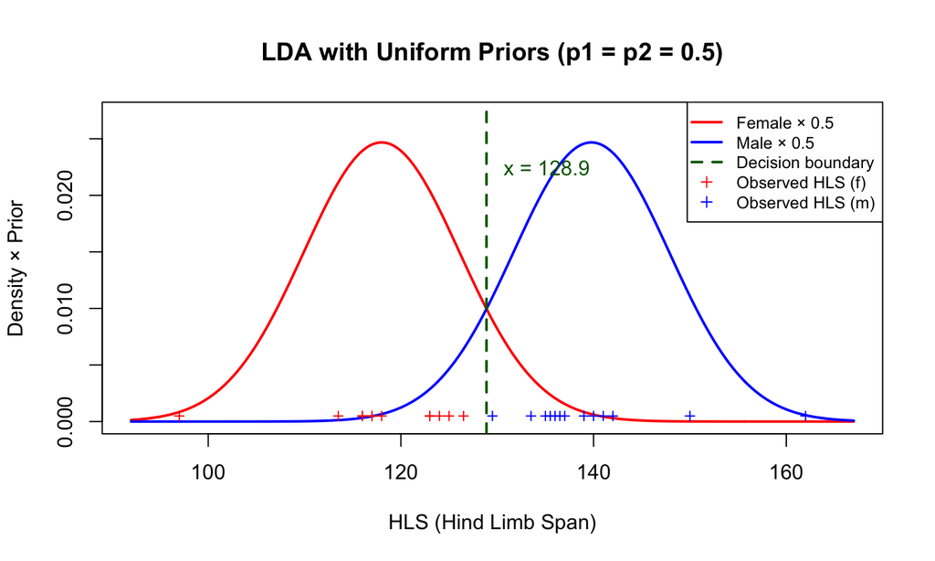

## LDA with non-uniform priors

If we assume males are more abundant: \(p_1 = 0.2\) (female) and \(p_2=0.8\) (male)

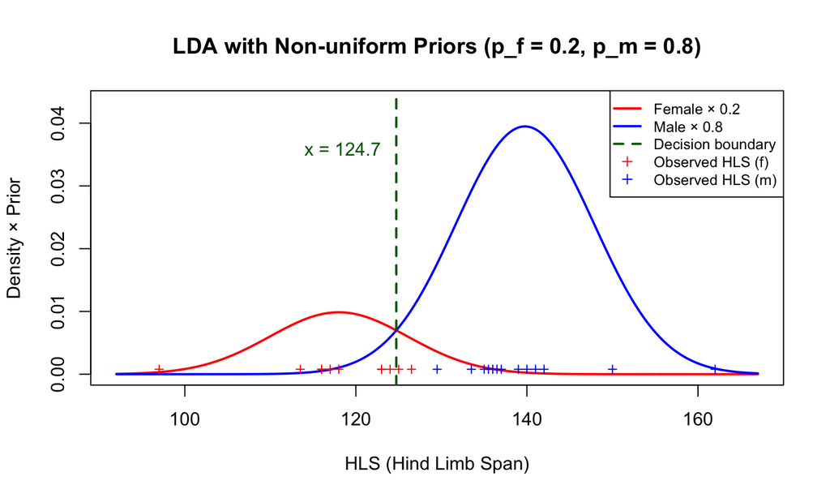

## Decision boundary with lizard data (uniform prior)

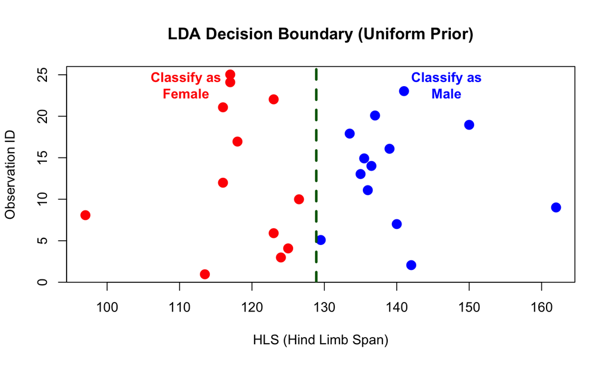

## Decision boundary with lizard data (non-uniform prior)

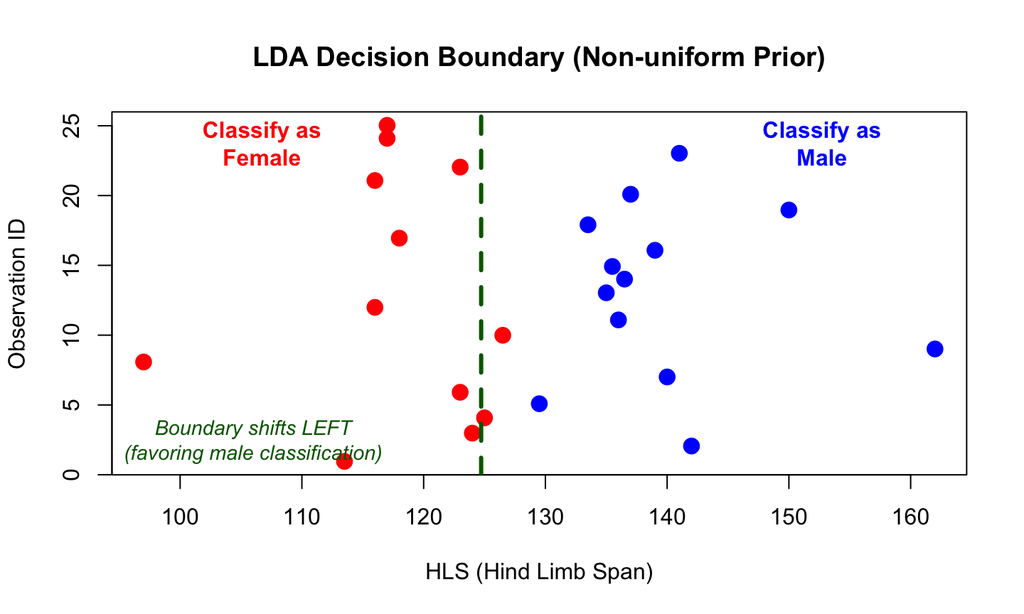

## LDA in RStudio

predict gives classes and \(P(c_i|x_1^*)\) - *posterior* probability.

Remember \(P(c_i|x_1^*) \propto f_i(x_1^*)\cdot p_i\) for \(i=1,2\) here:

```r
DAModel.1 <- MASS::lda(Sex~HLS, data=Lizard, prior=rep(0.5,2))
preds <- predict(DAModel.1,data=Lizard)
preds$class[1:18]
```

```
##  [1] f m f f m f m f m f m f m m m m f m
## Levels: m f
```

```r
preds$posterior[1:3,]
```

```
##            m          f
## 1 0.00590689 0.99409311
## 2 0.98750273 0.01249727
## 3 0.16418501 0.83581499
```

## Confusion matrix (uniform prior)

The fit is presented as a *confusion matrix* and *accuracy* of classification

```r
confusion(Lizard$Sex, preds$class) # confusion matrix
```

```
##          True
## Predicted  m  f
##   m       13  0
##   f        0 12
##   Total   13 12
##   Correct 13 12
##
## Proportions correct
## m f
## 1 1
##
## N correct/N total = 25/25 = 1
```

## LDA in R with non-uniform priors

```r
DAModel.2 <- lda(Sex~HLS, data=Lizard, prior=c(0.8, 0.2))
confusion(Lizard$Sex, predict(DAModel.2)$class) # confusion matrix
```

```
##          True
## Predicted  m  f
##   m       13  2
##   f        0 10
##   Total   13 12
##   Correct 13 10
##
## Proportions correct
##         m         f
## 1.0000000 0.8333333
##
## N correct/N total = 23/25 = 0.92
```

Notice how the classification changes when we favor males!

## The default choice prior

In RStudio the default choice of prior is “empirical” which means that the priors are set equal to the group proportions in the data set

Hence, if there are \(n_i\) observations in group \(i\) and \(N = \sum_{i=1}^K n_i\) is the total observation number, then

\[\widehat{p}_i = \frac{n_i}{N}\]

This may be reasonable if one assumes that the sample sizes reflect population sizes.

## LDA in R with the default priors

```r
DAModel.2 <- lda(Sex~HLS, data=Lizard)
DAModel.2$prior
```

```
##    m    f
## 0.52 0.48
```

```
##          True
## Predicted  m  f
##   m       13  0
##   f        0 12
##   Total   13 12
##   Correct 13 12
##
## Proportions correct
## m f
## 1 1
##
## N correct/N total = 25/25 = 1
```

## Extending LDA to multiple covariates

Once we understand LDA with one covariate, the extension to multiple covariates is straightforward:

- Instead of univariate normal distributions, we use *multivariate normal* distributions
- The variance \(\sigma^2\) becomes a covariance matrix \(\Sigma\) (still common across classes)
- The decision boundary becomes a line, plane or hyperplane (linear in the predictor space)

**Next**: Let’s recall the bivariate normal distribution first

## The Bivariate Normal Distribution

For two random variables \((X_1, X_2)\), the bivariate normal distribution is characterized by:

- **Means**: \(\mu_1\) and \(\mu_2\)
- **Variances**: \(\sigma_1^2\) and \(\sigma_2^2\)
- **Correlation**: \(\rho\) (or covariance \(\sigma_{12}\)), where \(\rho = \frac{\sigma_{12}}{\sigma_1\cdot\sigma_2}\)

The **covariance matrix** combines all this information:

\[\Sigma = \begin{pmatrix} \sigma_1^2 & \sigma_{12} \\ \sigma_{12} & \sigma_2^2 \end{pmatrix}\]

The density forms an elliptical “hill” in 3D space.

## Visualizing Bivariate Normal

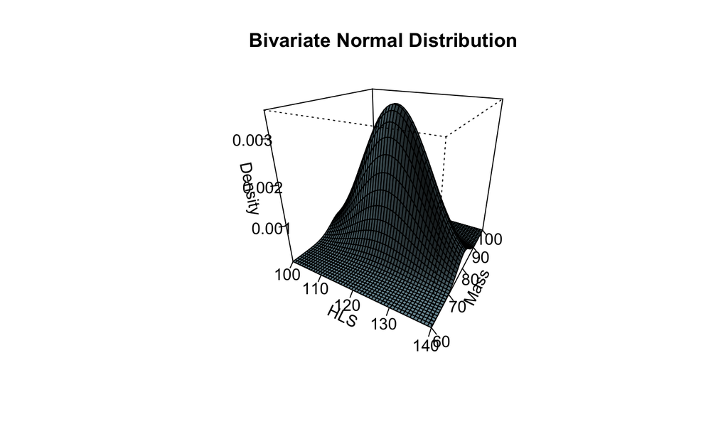

## Bivariate Normal: Contour View (no correlation)

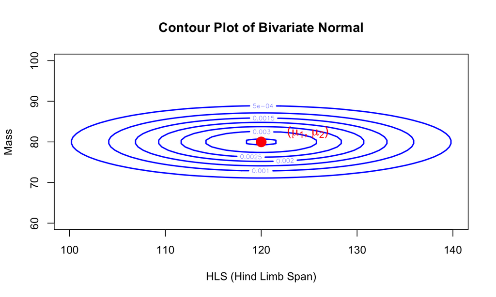

## Bivariate Normal: Contour View (positive correlation)

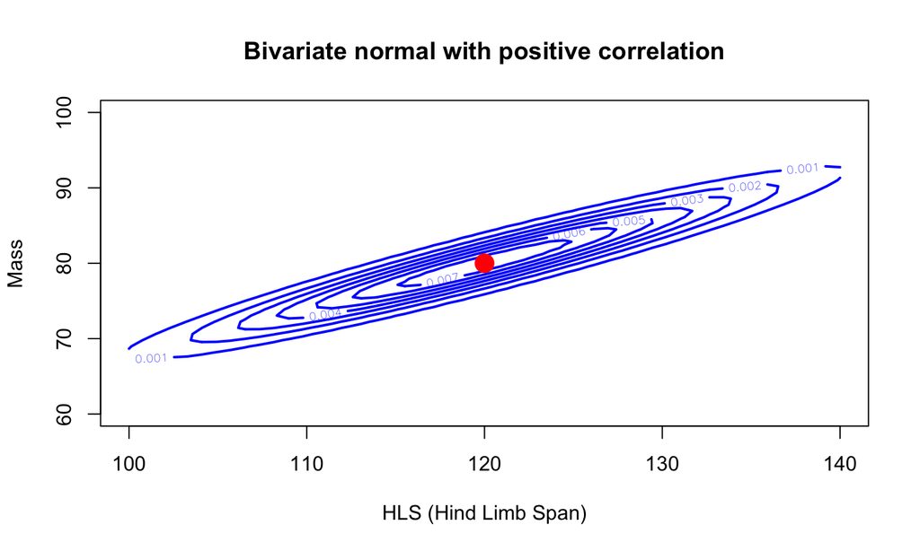

## LDA with Two Covariates: The Setup

For lizard example with HLS and Mass (\(p=2\)):

**Female class** (\(c_1\)): \[\mathbf{X}|c_1 \sim N_2(\boldsymbol{\mu}_1, \boldsymbol{\Sigma})\]

**Male class** (\(c_2\)): \[\mathbf{X}|c_2 \sim N_2(\boldsymbol{\mu}_2, \boldsymbol{\Sigma})\]

**Assume**: *Same covariance* matrix \(\boldsymbol{\Sigma}\) for both classes

The classification rule becomes: \[\text{Classify as female if: } f_1(\mathbf{x}^*) \cdot p_1 \geq f_2(\mathbf{x}^*) \cdot p_2\]

where \(f_i\) is the bivariate normal density for class \(i\).

## LDA with two predictors in R

```r
# LDA with two predictors: HLS and Mass
lda_2var <- lda(Sex ~ HLS + Mass,data  = Lizard, prior = c(0.5, 0.5))
pred_2var <- predict(lda_2var)$class
confusion(Lizard$Sex, pred_2var)
```

```
##          True
## Predicted  m  f
##   m       13  0
##   f        0 12
##   Total   13 12
##   Correct 13 12
##
## Proportions correct
## m f
## 1 1
##
## N correct/N total = 25/25 = 1
```

## Visualizing Bivariate LDA for Lizards

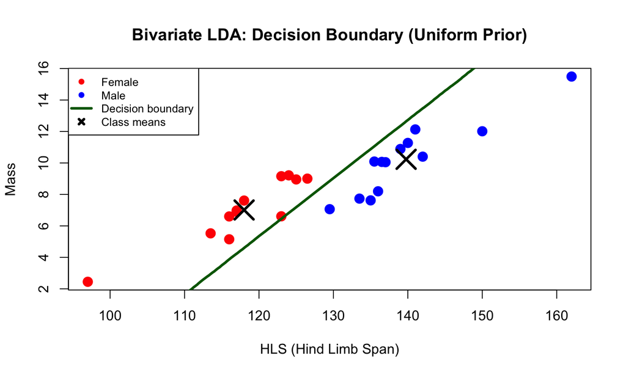

## Tri-variate discrimination

Using all variables (\(p=3\))

A linear discriminator is a flat plane in the 3D-space

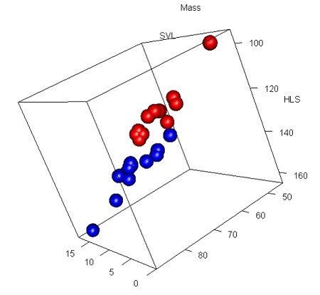

## LDA with three predictors

```r
lda_3var <- lda(Sex ~ HLS + Mass + SVL,data  = Lizard, prior = c(0.5, 0.5))
pred_3var <- predict(lda_3var)$class
confusion(Lizard$Sex, pred_3var)
```

```
##          True
## Predicted  m  f
##   m       13  0
##   f        0 12
##   Total   13 12
##   Correct 13 12
##
## Proportions correct
## m f
## 1 1
##
## N correct/N total = 25/25 = 1
```

## From LDA to QDA: Relaxing the assumption

**LDA assumption**: All classes share the same variance \(\sigma^2\) or covariance matrix \(\boldsymbol{\Sigma}\)

**QDA relaxation**: Each class \(i\) has its own variance \(\sigma_i^2\) or covariance matrix \(\boldsymbol{\Sigma}_i\)

**Consequences**: - More flexible (can capture different variability patterns) - Decision boundaries become **quadratic** (curved surfaces) - More parameters to estimate (may overfit with small data)

**When to use QDA**: When classes clearly have different spreads/correlations. Or when we see a clearly non-linear decision boundary

## Why is QDA “Quadratic”?

**Key difference**: Each class has its own variance \(\sigma_1^2\) and \(\sigma_2^2\) and \(p_1\) = \(p_2\)

Decision boundary where \(f_1(x) \cdot p_1 = f_2(x) \cdot p_2\):

\(\frac{0.5}{\sqrt{2\pi\sigma_1^2}}e^{-\frac{(x-\mu_1)^2}{2\sigma_1^2}} = \frac{0.5}{\sqrt{2\pi\sigma_2^2}}e^{-\frac{(x-\mu_2)^2}{2\sigma_2^2}}\)taking logarithms: \(-\frac{1}{2}\log(\sigma_1^2) - \frac{(x-\mu_1)^2}{2\sigma_1^2} = - \frac{1}{2}\log(\sigma_2^2) - \frac{(x-\mu_2)^2}{2\sigma_2^2}\)

**Quadratic equation in** \(x\) since \(x^2\) is no longer removed

\(ax^2 + bx + c = 0\)

**Result**: porabolic **boundaries** in higher dimensions

## Running QDA with Different covariances (2D)

```r
# Fit QDA with two predictors (HLS and Mass)
qda_biv <- qda(Sex ~ HLS + Mass, data = Lizard, prior = c(0.5, 0.5))
qda_biv <- predict(qda_biv)$class
confusion(Lizard$Sex, qda_biv)
```

```
##          True
## Predicted  m  f
##   m       13  0
##   f        0 12
##   Total   13 12
##   Correct 13 12
##
## Proportions correct
## m f
## 1 1
##
## N correct/N total = 25/25 = 1
```

## QDA: Visualizing Different Covariances

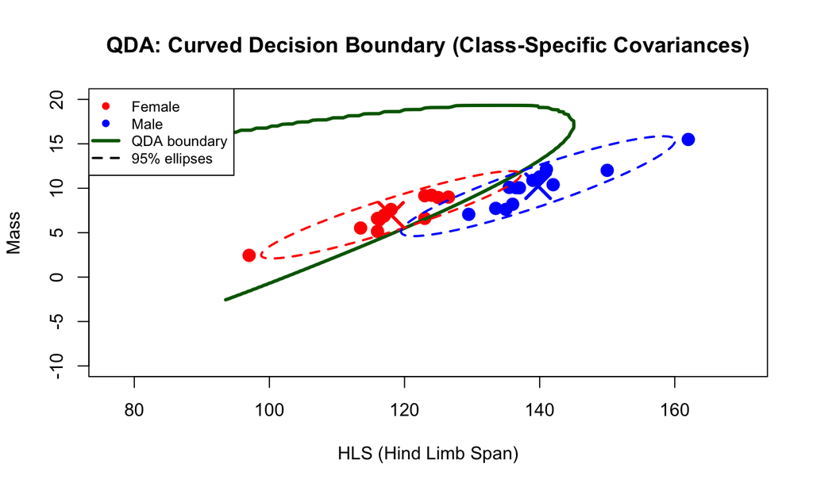

## LDA vs QDA: Key Differences Summary

|  | **LDA** | **QDA** |
| --- | --- | --- |
| **Covariance** | Common \(\boldsymbol{\Sigma}\) | Class-specific \(\boldsymbol{\Sigma}_i\) |
| **Decision boundary** | Linear (hyperplane) | Quadratic (curved) |
| **Parameters** | Fewer | More |
| **Flexibility** | Less flexible | More flexible |
| **Risk** | Underfitting | Overfitting (small data) |
| **Best for** | Similar class spreads | Different class spreads |

## Model selection/evaluation

- We often want to compare the performance of different classifiers
- Many available statistics for this purpose, but we will consider the accuracy or the apparent error rate (APER)
- The performance of a classifier may, as we’ve seen be summarized in a *confusion matrix*

## Example - SVL as predictor

We shall use snout-vent length (in millimeters)

```r
DAModel.4 <- qda(Sex~SVL, data=Lizard, prior=rep(0.5,2))
confusion(Lizard$Sex, predict(DAModel.4)$class) # confusion matrix
```

```
##          True
## Predicted  m  f
##   m       10  2
##   f        3 10
##   Total   13 12
##   Correct 10 10
##
## Proportions correct
##         m         f
## 0.7692308 0.8333333
##
## N correct/N total = 20/25 = 0.8
```

## Metrics to check

|  | True Male | True Female |
| --- | --- | --- |
| Pred Male | 10 | 2 |
| Pred Female | 3 | 10 |

- \(P(\text{classify as female} | \text{true male}) = 3/13 \approx 0.23\) (**FNR** for males)
- \(P(\text{classify as male} | \text{true female}) = 2/12 \approx 0.17\) (**FPR** for males)
- Apparent error rate (APER) = \(\frac{3 + 2}{25} = 0.2\)
- Accuracy = \(1 - \text{APER} = \frac{10+10}{25} = 0.8\)

## Validation of the model

- We need **new test data** to get an honest classification error.
- Alternatively perform **cross-validation**:
  - **Leave-one-out Cross-Validation (LOOCV)**: available in R, choose the option `CV = TRUE`.
  - **k-fold Cross-Validation**: split the data into \(k\) folds, fit the model on \(k-1\) folds and test on the remaining fold, repeat \(k\) times and average the error.
- Another option is the **bootstrap**:
  - Draw many bootstrap samples from the training data, refit the classifier on each sample, and evaluate predictions on the observations left out (or on the original data) to estimate variability and bias of the error rate.

## LOOCV: Leave One Out Cross Validation:

1. for \(i\) = 1, …, n
2. Leave out observation \(i\) from complete data and fit model.
3. Classify observation i

For each observation we can check if it is was correctly classified. Cross Validation (CV) is a good alternative for model evaluation when we don’t have fresh test data.

We can use CV to find the best model from a set or just to evaluate a given model.

## Example - Cross Validation (CV = TRUE)

`res$class` contains these cross‑validated predicted classes for all observations

```r
res <- lda(Sex ~ SVL, data = Lizard,
prior = c(0.5, 0.5), CV = TRUE)
res$class
```

```
##  [1] f m m f f f m f m m m f f m m m f f m m f m m f f
## Levels: m f
```

## Confusion matrix for CV

```r
res <- qda(Sex ~ SVL, data=Lizard,
prior = c(0.5, 0.5), CV = TRUE)
confusion(Lizard$Sex, res$class)
```

```
##          True
## Predicted  m  f
##   m       10  4
##   f        3  8
##   Total   13 12
##   Correct 10  8
##
## Proportions correct
##         m         f
## 0.7692308 0.6666667
##
## N correct/N total = 18/25 = 0.72
```

Typically, accuracy goes down, and the errors increase.

## Iris (3 classes): LDA with two predictors

```r
iris_lda <- lda(Species ~ Petal.Length + Petal.Width, data  = iris)
iris_cv <- lda(Species ~ Petal.Length + Petal.Width, data  = iris, CV    = TRUE)
confusion(iris$Species, iris_cv$class)
```

```
##             True
## Predicted    setosa versicolor virginica
##   setosa         50          0         0
##   versicolor      0         48         4
##   virginica       0          2        46
##   Total          50         50        50
##   Correct        50         48        46
##
## Proportions correct
##     setosa versicolor  virginica
##       1.00       0.96       0.92
##
## N correct/N total = 144/150 = 0.96
```

## Iris (3 classes): LDA decision regions

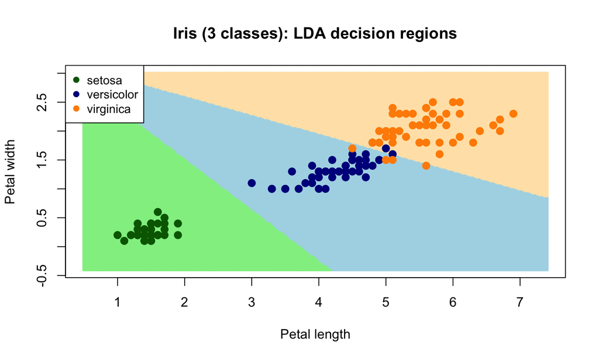

## Iris (3 classes): QDA with two predictors

```r
iris_qda <- qda(Species ~ Petal.Length + Petal.Width, data  = iris)
iris_qda_cv <- qda(Species ~ Petal.Length + Petal.Width, data  = iris,
                   CV = TRUE)
confusion(iris$Species, iris_qda_cv$class)
```

```
##             True
## Predicted    setosa versicolor virginica
##   setosa         50          0         0
##   versicolor      0         48         3
##   virginica       0          2        47
##   Total          50         50        50
##   Correct        50         48        47
##
## Proportions correct
##     setosa versicolor  virginica
##       1.00       0.96       0.94
##
## N correct/N total = 145/150 = 0.9666667
```

## Iris (3 classes): LDA vs QDA decision regions

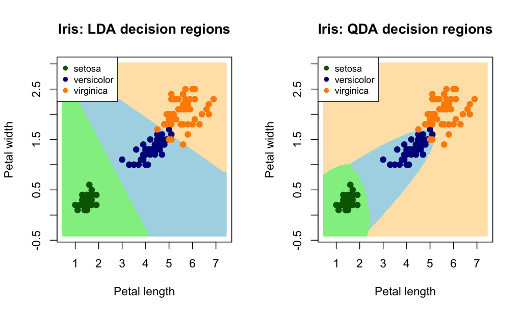

## k-nearest neighbours (KNN)

- Non-parametric classifier: no assumptions like normality or equal covariances.
- For a new **x**, find the **k** closest training points, then classify by majority vote.
- Small **k** → very flexible, can overfit noise.
- Large **k** → smoother decision boundary, higher bias, lower variance.
- Choice of k should be based on **validation**, not training accuracy.

## Visual intuition for KNN (k = 3)

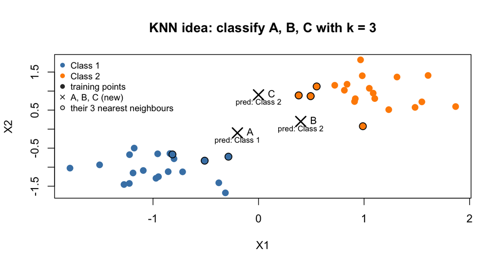

- A, B and C are **new** points to classify.
- For each, we look at its 3 nearest neighbours and take the majority class.
- Labels like `pred: Class 1` show the KNN decision for each new point.

## KNN in R: basic usage

- We use the `knn` function in the **class** package.
- Inputs: training predictors `train`, new predictors `test`, class labels `cl`, and `k`.
- Output: predicted class labels for the `test` observations.

```r
library(class)
# Simple example (toy data from previous slide)
train <- X
cl    <- Y
# Predict classes for the new points A, B, C with k = 3
k <- 3
pred_ABC <- knn(train = train, test = X_new, cl = cl, k = k)
pred_ABC
```

```
## [1] Class 1 Class 2 Class 2
## Levels: Class 1 Class 2
```

- `pred_ABC` contains the KNN classifications for A, B, and C.

## Iris data: 5-KNN with 2 predictors

```
##             True
## Predicted    setosa versicolor virginica
##   setosa         10          0         0
##   versicolor      0         15         0
##   virginica       0          0         5
##   Total          10         15         5
##   Correct        10         15         5
##
## Proportions correct
##     setosa versicolor  virginica
##          1          1          1
##
## N correct/N total = 30/30 = 1
```

- This shows how to fit and evaluate a KNN classifier on the iris data.
- We use a train/test split to get a more **honest** estimate of accuracy.

## Iris data: 1-KNN with 2 predictors

```
##             True
## Predicted    setosa versicolor virginica
##   setosa         10          0         0
##   versicolor      0         14         0
##   virginica       0          1         5
##   Total          10         15         5
##   Correct        10         14         5
##
## Proportions correct
##     setosa versicolor  virginica
##  1.0000000  0.9333333  1.0000000
##
## N correct/N total = 29/30 = 0.9666667
```

## Iris: KNN decision boundaries

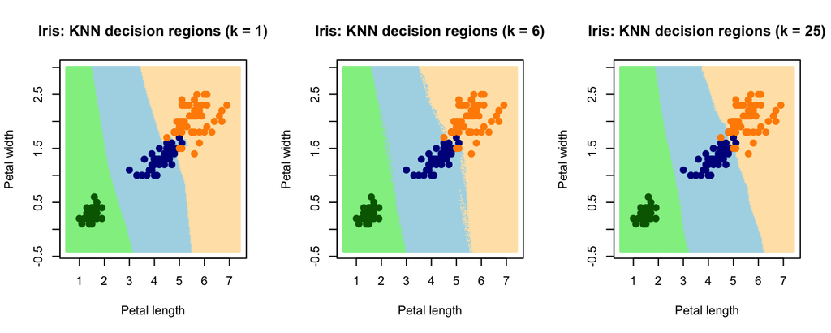

## Other classifiers

There is a wide range of classifiers available in R, e.g.:

- Logistic regression (**glm**)
- Support Vector Machines (**svm**)
- Random Forest (**randomForest**)
- Neural Networks (**nnet**)

## Practical information: upcoming weeks

- Next two **lectures** (PCA and PCA regression) will be given as **video recordings from last years**.
- During the scheduled lecture slots, we will **stream two invited talks** that connect to the course topics (see next slides).
- Please make sure to **watch the PCA and PCA regression videos** before the Q&A / exercise sessions.

## Invited talk on Mar 24:

- Speaker: **Andrew McInerney**
- Title: “[A Smooth Information Criterion for Selection and Fusion of Categorical Predictors](https://www.mn.uio.no/math/english/research/groups/statistics-data-science/events/seminars/spring_2026/andrew_mcInerney.html)”
- Time and place: **Mar 24, 2026, 14:15–15:15** (during our normal lecture slot).
- Topic in brief: smooth information-criterion-based method within GLMs that
  - performs **factor selection** and **fusion of categorical levels**,
  - replaces the discrete L0-type BIC penalty with a **smooth surrogate**,
  - avoids tuning-parameter search and scales to many levels.
- This links to our course theme of **model selection**.

## Invited talk on Apr 7:

- Speaker: **Aliaksandr Hubin**
- Title: “[Explainable Bayesian deep learning through input-skip Latent Binary Bayesian Neural Networks](https://www.mn.uio.no/math/english/research/groups/statistics-data-science/events/seminars/spring_2026/aliaksandr-hubin.html)”
- Time and place: **Apr 7, 2026, 14:15–15:15**.
- Topic in brief: input-skip LBBNNs (ISLaB) that
  - allow covariates to **skip to later layers or be excluded** entirely,
  - yield extremely **sparse** networks (over 99–99.9% weight reduction) while keeping high accuracy,
  - provide **built-in explanations** via active paths and uncertainty-aware predictions.
- This connects directly to our discussions of classification and discrimination.